# 阿里彩票

彩种报告 (Part II)

雷欧

2020-11-03

# 1 简介

```r
## 3210448065@qq.com
## leiou123

## 2849108450@qq.com
## leiou123
## https://rstudio.cloud/project/1198888

if(!require('BBmisc')) {install.packages('BBmisc', dependencies = TRUE,
                                         INSTALL_opts = '--no-lock')}
require('BBmisc')
pkg <- c('plyr', 'tidyverse', 'magrittr', 'readr', 'readxl', 'tidyr', 'MASS',
         'knitr', 'kableExtra', 'forecast', 'formattable', 'DT', 'echarts4r',
         'lubridate', 'highcharter', 'htmltools', 'readr', 'pryr', 'sparklyr',
         'lme4', 'microbenchmark', 'polynom', 'multipol', 'splines', 'leaps',
         'highr', 'dplyr', 'pacman', 'lme4', 'nlme')

#plyr::l_ply(pkg, require, quietly = TRUE, character.only = TRUE, .print = FALSE)
suppressAll(lib(pkg))
rm(pkg)
#sc <- spark_connect(master = 'local')
```

当初在推广部门，**宋祖：宋组长**给个样本数据，我就尝试使用线性模型和时间序列`arima`模型分析了进粉业绩，详情请参考[阿里彩票 - 分析样本数据](https://rpubs.com/englianhu/ali)[^1]。然后转到运维部门分析了[阿里彩票 - 彩种报告](https://rpubs.com/englianhu/ali_bet_type)，只是基本分析彩种，将数据视觉化；此商业分析进一步使用混合线性模型分析数据，预测彩种盈利。

# 2 数据

读取样本数据。

```r
## 读取数据
fls <- suppressWarnings(list.files('data/彩种'))
smp <- fls %>% llply(., function(x) {
    dtt <- x %>% str_replace_all('.xls', '') %>% ymd
    smpp <- read_excel(paste0('data/彩种/', x)) %>%
      .[-nrow(.),]
    data.frame('日期' = dtt, smpp)
}) %>% bind_rows %>%
    as_tibble %>%
    mutate('彩种名称' = factor(彩种名称), '盈率' = as.numeric(percent(盈率))) %>%
    mutate_if(is.character, as.numeric)
rm(fls)

nm <- names(smp)
names(smp) <- c('Date', 'Type', 'Bettor', 'Turnover', 'Won', 'Cancelled', 'Rebates', 'Profit', 'Profit_rate')

## 转化为大数据
smp2 <- smp
#smp2 <- copy_to(sc, smp2)

# smp2 %>%
#   as_tibble %>%
#   kbl('html', caption = '每日投注人数', escape = F) %>%
#   kable_styling(
#     bootstrap_options = c('striped', 'hover', 'condensed', 'responsive')) %>%
#   scroll_box(height = '400px')
```

```r
smp %>% glimpse
```

```
## Rows: 4,050
## Columns: 9
## $ Date        <date> 2020-05-27, 2020-05-27, 2020-05-27, 2020-05-27, 2020-05-…
## $ Type        <fct> 1分快3, 极速快3, 3分快3, 龙虎斗, 5分快3, 传统1分赛车, 骰宝, 传统1分彩, 1分六合, 1分彩…
## $ Bettor      <dbl> 698, 150, 117, 45, 44, 15, 10, 19, 29, 38, 14, 32, 8, 19,…
## $ Turnover    <dbl> 7994708.00, 1817943.00, 279209.00, 201525.00, 121834.00, …
## $ Won         <dbl> 7649465.34, 1788182.30, 264210.09, 196699.20, 117366.68, …
## $ Cancelled   <dbl> 85262.00, 0.00, 4180.00, 0.00, 77.00, 3656.00, 0.00, 0.00…
## $ Rebates     <dbl> 10892.66, 3426.23, 392.13, 748.04, 60.53, 33.35, 779.70, …
## $ Profit      <dbl> 334350.00, 26334.47, 14606.78, 4077.76, 4406.80, 4494.07,…
## $ Profit_rate <dbl> 0.0418, 0.0145, 0.0523, 0.0202, 0.0362, 0.0535, 0.1530, 0…
```

*图表2.1：数据简介*

上图[阿里彩票 - 彩种报告](https://rpubs.com/englianhu/ali_bet_type)显示从2020-05-27到2020-07-24的报表数据，一共有4050个观测值。

# 3 统计模型

## 3.1 多元相互式模型

```r
# smp2 %>%
#     spark_apply(
#         function(e) summary(lm(Profit ~ Turnover * Bettor * Won, e))$r.squared,
#         names = 'r.squared',
#         group_by = 'Type')

# 每日观测值
smp2 %>%
    ddply(.(Date), nrow) %>%
    as_tibble %>% dplyr::rename(n = V1) %>%
  ## https://www.colorhexa.com/color-names
  mutate(n = color_tile('#007fff', 'white')(n)) %>% #azure
  kbl('html', caption = '每日投注人数', escape = F, align = 'c') %>%
  kable_styling(
    bootstrap_options = c('striped', 'hover', 'condensed', 'responsive')) %>%
  scroll_box(height = '400px')
```

每日投注人数

| Date | n |
| --- | --- |
| 2020-05-27 | 69 |
| 2020-05-28 | 68 |
| 2020-05-29 | 71 |
| 2020-05-30 | 68 |
| 2020-05-31 | 67 |
| 2020-06-01 | 68 |
| 2020-06-02 | 70 |
| 2020-06-03 | 69 |
| 2020-06-04 | 70 |
| 2020-06-05 | 73 |
| 2020-06-06 | 71 |
| 2020-06-07 | 72 |
| 2020-06-08 | 68 |
| 2020-06-09 | 69 |
| 2020-06-10 | 72 |
| 2020-06-11 | 71 |
| 2020-06-12 | 67 |
| 2020-06-13 | 71 |
| 2020-06-14 | 72 |
| 2020-06-15 | 70 |
| 2020-06-16 | 70 |
| 2020-06-17 | 72 |
| 2020-06-18 | 71 |
| 2020-06-19 | 67 |
| 2020-06-20 | 68 |
| 2020-06-21 | 66 |
| 2020-06-22 | 68 |
| 2020-06-23 | 68 |
| 2020-06-24 | 71 |
| 2020-06-25 | 68 |
| 2020-06-26 | 68 |
| 2020-06-27 | 69 |
| 2020-06-28 | 68 |
| 2020-06-29 | 66 |
| 2020-06-30 | 66 |
| 2020-07-01 | 67 |
| 2020-07-02 | 65 |
| 2020-07-03 | 64 |
| 2020-07-04 | 66 |
| 2020-07-05 | 69 |
| 2020-07-06 | 68 |
| 2020-07-07 | 65 |
| 2020-07-08 | 71 |
| 2020-07-09 | 67 |
| 2020-07-10 | 68 |
| 2020-07-11 | 70 |
| 2020-07-12 | 69 |
| 2020-07-13 | 69 |
| 2020-07-14 | 63 |
| 2020-07-15 | 69 |
| 2020-07-16 | 70 |
| 2020-07-17 | 66 |
| 2020-07-18 | 72 |
| 2020-07-19 | 73 |
| 2020-07-20 | 69 |
| 2020-07-21 | 71 |
| 2020-07-22 | 66 |
| 2020-07-23 | 65 |
| 2020-07-24 | 66 |

*图表3.1.1：每日观测值*

我不晓得最优模型，先以完整数据观测值为标准，以下乃`多元相互式模型`[^2]。

```r
# lm1 <- lm(Profit ~ Type * Bettor * Turnover * Won * Cancelled * Rebates, smp2)

# m.aic.backward1 <- step(lm1, direction = 'backward', trace = 1)
# m.aic.backward2 <- step(lm1)

md <- list(
  m00 = lm(Profit ~ Date * Type * Bettor * Turnover * Won * Cancelled * Rebates, smp2) %>% extractAIC,
  m01 = lm(Profit ~ Type * Bettor * Turnover * Won * Cancelled * Rebates, smp2) %>% extractAIC,
  m02 = lm(Profit ~ Type * Bettor * Turnover * Won * Cancelled, smp2) %>% extractAIC,
  m03 = lm(Profit ~ Type * Bettor * Turnover * Won * Rebates, smp2) %>% extractAIC,
  m04 = lm(Profit ~ Type * Bettor * Turnover * Cancelled * Rebates, smp2) %>% extractAIC,
  m05 = lm(Profit ~ Type * Bettor * Won * Cancelled * Rebates, smp2) %>% extractAIC,
  m06 = lm(Profit ~ Type * Turnover * Won * Cancelled * Rebates, smp2) %>% extractAIC,
  m07 = lm(Profit ~ Bettor * Turnover * Won * Cancelled * Rebates, smp2) %>% extractAIC,
  m08 = lm(Profit ~ Type * Bettor * Turnover * Won, smp2) %>% extractAIC,
  m09 = lm(Profit ~ Type * Bettor * Turnover * Rebates, smp2) %>% extractAIC,
  m10 = lm(Profit ~ Type * Won * Cancelled * Rebates, smp2) %>% extractAIC,
  m11 = lm(Profit ~ Type * Bettor * Turnover * Cancelled, smp2) %>% extractAIC,
  m12 = lm(Profit ~ Type * Bettor * Won * Rebates, smp2) %>% extractAIC,
  m13 = lm(Profit ~ Type * Bettor * Won * Cancelled, smp2) %>% extractAIC,
  m14 = lm(Profit ~ Type * Turnover * Won * Rebates, smp2) %>% extractAIC,
  m15 = lm(Profit ~ Type * Turnover * Cancelled * Rebates, smp2) %>% extractAIC,
  m16 = lm(Profit ~ Type * Turnover * Won * Rebates, smp2) %>% extractAIC,
  m17 = lm(Profit ~ Type * Won * Cancelled * Rebates, smp2) %>% extractAIC,
  m18 = lm(Profit ~ Bettor * Turnover * Won * Cancelled, smp2) %>% extractAIC,
  m19 = lm(Profit ~ Bettor * Turnover * Won * Rebates, smp2) %>% extractAIC,
  m20 = lm(Profit ~ Bettor * Turnover * Cancelled * Rebates, smp2) %>% extractAIC,
  m21 = lm(Profit ~ Type * Bettor * Turnover * Won * Cancelled * Rebates, smp2) %>% extractAIC,
  m22 = lm(Profit ~ Turnover * Won * Cancelled * Rebates, smp2) %>% extractAIC) %>%
  ldply %>%
  as_tibble %>%
  dplyr::rename(df = V1, AIC = V2)

## save files, easier to read.
microbenchmark(
   save(md, file = 'data/md.rda'),
   write_rds(md, 'data/md.rds'),
   saveRDS(md, file = 'data/md.rds'))
#Unit: microseconds
#                                expr     min       lq     mean   median      uq     max neval
#      save(md, "data/md.rda") 114.666 130.9080 135.2061 134.3990 137.111 174.759   100
# write_rds(md, "data/md.rds") 111.098 120.6370 126.8601 125.1935 129.534 178.582   100
#   saveRDS(md, "data/md.rds") 143.649 160.3135 178.6935 183.2730 186.673 358.803   100
```

1. $m00 = lm(Profit \sim Date * Type * Bettor * Turnover * Won * Cancelled * Rebates, smp2)$
2. $m01 = lm(Profit \sim Type * Bettor * Turnover * Won * Cancelled * Rebates, smp2)$
3. $m02 = lm(Profit \sim Type * Bettor * Turnover * Won * Cancelled, smp2)$
4. $m03 = lm(Profit \sim Type * Bettor * Turnover * Won * Rebates, smp2)$
5. $m04 = lm(Profit \sim Type * Bettor * Turnover * Cancelled * Rebates, smp2)$
6. $m05 = lm(Profit \sim Type * Bettor * Won * Cancelled * Rebates, smp2)$
7. $m06 = lm(Profit \sim Type * Turnover * Won * Cancelled * Rebates, smp2)$
8. $m07 = lm(Profit \sim Bettor * Turnover * Won * Cancelled * Rebates, smp2)$
9. $m08 = lm(Profit \sim Type * Bettor * Turnover * Won, smp2)$
10. $m09 = lm(Profit \sim Type * Bettor * Turnover * Rebates, smp2)$
11. $m10 = lm(Profit \sim Type * Won * Cancelled * Rebates, smp2)$
12. $m11 = lm(Profit \sim Type * Bettor * Turnover * Cancelled, smp2)$
13. $m12 = lm(Profit \sim Type * Bettor * Won * Rebates, smp2)$
14. $m13 = lm(Profit \sim Type * Bettor * Won * Cancelled, smp2)$
15. $m14 = lm(Profit \sim Type * Turnover * Won * Rebates, smp2)$
16. $m15 = lm(Profit \sim Type * Turnover * Cancelled * Rebates, smp2)$
17. $m16 = lm(Profit \sim Type * Turnover * Won * Rebates, smp2)$
18. $m17 = lm(Profit \sim Type * Won * Cancelled * Rebates, smp2)$
19. $m18 = lm(Profit \sim Bettor * Turnover * Won * Cancelled, smp2)$
20. $m19 = lm(Profit \sim Bettor * Turnover * Won * Rebates, smp2)$
21. $m20 = lm(Profit \sim Bettor * Turnover * Cancelled * Rebates, smp2)$
22. $m21 = lm(Profit \sim Type * Bettor * Turnover * Won * Cancelled * Rebates, smp2)$
23. $m22 = lm(Profit \sim Turnover * Won * Cancelled * Rebates, smp2)$

*方程3.1：多元相互式模型*

以上模型使用$lm()$函数，从模型$m00 \sim m22$，[How to Make Beautiful Tables in R](https://rfortherestofus.com/2019/11/how-to-make-beautiful-tables-in-r/)有很多桌表程序包，以下咱们比较下**最优模型**。

### 3.1.1 formattable

```r
md <- read_rds('data/md.rds')
md2 <- md

## https://www.colorhexa.com/color-names
md2 %>%
  formattable(
    list(
        AIC = formatter('span', style = x ~ formattable::style(
            color = ifelse(rank(x) <= 3, 'darkgoldenrod', 'grey')),
            x ~ paste0(round(x, 2),
                       ' (rank: ', sprintf('%1.f', rank(x)), ')')))) %>%
    mutate(df = color_tile('#2a52be', 'white')(df)) #colbalt
```

| .id | df | AIC |
| --- | --- | --- |
| m00 | 3191 | -49080.6 (rank: 1) |
| m01 | 1869 | -46349.75 (rank: 8) |
| m02 | 1016 | 54000.98 (rank: 13) |
| m03 | 1162 | -46316.44 (rank: 10) |
| m04 | 991 | 75832.5 (rank: 17) |
| m05 | 990 | 76036.27 (rank: 21) |
| m06 | 992 | -46487.54 (rank: 7) |
| m07 | 32 | -46985.58 (rank: 2) |
| m08 | 612 | 53750.15 (rank: 12) |
| m09 | 596 | 75620.65 (rank: 15) |
| m10 | 513 | 76004.62 (rank: 20) |
| m11 | 527 | 76125.69 (rank: 22) |
| m12 | 595 | 75842.57 (rank: 18) |
| m13 | 526 | 76464.73 (rank: 23) |
| m14 | 597 | -46690.31 (rank: 6) |
| m15 | 514 | 75815.62 (rank: 16) |
| m16 | 597 | -46690.31 (rank: 6) |
| m17 | 513 | 76004.62 (rank: 20) |
| m18 | 16 | 53141.39 (rank: 11) |
| m19 | 16 | -46963.81 (rank: 4) |
| m20 | 16 | 75023.42 (rank: 14) |
| m21 | 1869 | -46349.75 (rank: 8) |
| m22 | 16 | -46965.17 (rank: 3) |

*方程3.1.1：最优多元相互式模型AIC比较*

### 3.1.2 kableExtra

```r
## https://www.colorhexa.com/color-names
md2 %>%
  mutate(
    df = color_tile('#2a52be', 'white')(df), #colbalt
    AIC = ifelse(
      rank(AIC) <= 3,
      cell_spec(
        paste0(round(AIC, 2), ' (rank: ', sprintf('%1.f', rank(AIC)), ')'),
        'html', color = 'darkgoldenrod', bold = T),
      cell_spec(
        paste0(round(AIC, 2), ' (rank: ', sprintf('%1.f', rank(AIC)), ')'),
        'html', color = 'grey', italic = T))) %>%
  kbl('html', caption = '最优模型', escape = F, align = c('c', 'r', 'r')) %>%
  kable_styling(
    bootstrap_options = c('striped', 'hover', 'condensed', 'responsive')) %>%
  kable_material() %>%
  scroll_box(height = '400px')
```

最优模型

| .id | df | AIC |
| --- | --- | --- |
| m00 | 3191 | -49080.6 (rank: 1) |
| m01 | 1869 | -46349.75 (rank: 8) |
| m02 | 1016 | 54000.98 (rank: 13) |
| m03 | 1162 | -46316.44 (rank: 10) |
| m04 | 991 | 75832.5 (rank: 17) |
| m05 | 990 | 76036.27 (rank: 21) |
| m06 | 992 | -46487.54 (rank: 7) |
| m07 | 32 | -46985.58 (rank: 2) |
| m08 | 612 | 53750.15 (rank: 12) |
| m09 | 596 | 75620.65 (rank: 15) |
| m10 | 513 | 76004.62 (rank: 20) |
| m11 | 527 | 76125.69 (rank: 22) |
| m12 | 595 | 75842.57 (rank: 18) |
| m13 | 526 | 76464.73 (rank: 23) |
| m14 | 597 | -46690.31 (rank: 6) |
| m15 | 514 | 75815.62 (rank: 16) |
| m16 | 597 | -46690.31 (rank: 6) |
| m17 | 513 | 76004.62 (rank: 20) |
| m18 | 16 | 53141.39 (rank: 11) |
| m19 | 16 | -46963.81 (rank: 4) |
| m20 | 16 | 75023.42 (rank: 14) |
| m21 | 1869 | -46349.75 (rank: 8) |
| m22 | 16 | -46965.17 (rank: 3) |

*方程3.1.2：最优多元相互式模型AIC比较*

以下模型乃前三榜，分别是$m00$所有因素，包括时间序列参数因素；$m07$忽略彩种因素；$m22$只包括`投注金额`、`中奖金额`、`撤单金额`和`返点金额`因素。

1. $m00 = lm(Profit \sim Date * Type * Bettor * Turnover * Won * Cancelled * Rebates, smp2)$
2. $m07 = lm(Profit \sim Bettor * Turnover * Won * Cancelled * Rebates, smp2)$
3. $m22 = lm(Profit \sim Turnover * Won * Cancelled * Rebates, smp2)$

*方程3.2.1：多元相互式模型*

## 3.2 多元多项式模型

### 3.2.1 多元正交与原始多项式模型

#### 3.2.1.1 多元多项式基本模型

- [关于r：拟合由`leaps :: regsubsets`选择的多项式回归模型](https://www.codenong.com/51223897)有举例，还介绍了`leaps`程序包。
- [lm()中的poly(): raw和正交之間的差異](https://www.itdaan.com/tw/c0fe14f3fda89205497a506bf9e9c119)
- [R实现Polynomial regression](https://www.jianshu.com/p/8e6cc12d3036)
- [多项式回归（Polynomial regression）及线性检验](https://www.bioinfo-scrounger.com/archives/polynomial-regression)
- [How to interpret coefficients from a polynomial model fit?](https://stats.stackexchange.com/a/95952/68357)
- [poly() in lm(): difference between raw vs. orthogonal](https://stackoverflow.com/a/30000214/3806250)
- [Fitting Polynomial Regression in R](https://www.r-bloggers.com/2015/09/fitting-polynomial-regression-in-r)[^3]
- [Raw or orthogonal polynomial regression?](https://stats.stackexchange.com/questions/258307/raw-or-orthogonal-polynomial-regression)
- [Multivariate polynomials in R (`polynom` package)](https://cran.r-project.org/web/packages/multipol/vignettes/multipol.pdf)[^4]
- [Multivariate Polynomial Regression in R (Prediction)](https://stackoverflow.com/a/50261058/3806250)
- [Polynomial regression with multiple independent variables in R](https://stackoverflow.com/questions/45013550/polynomial-regression-with-multiple-independent-variables-in-r)

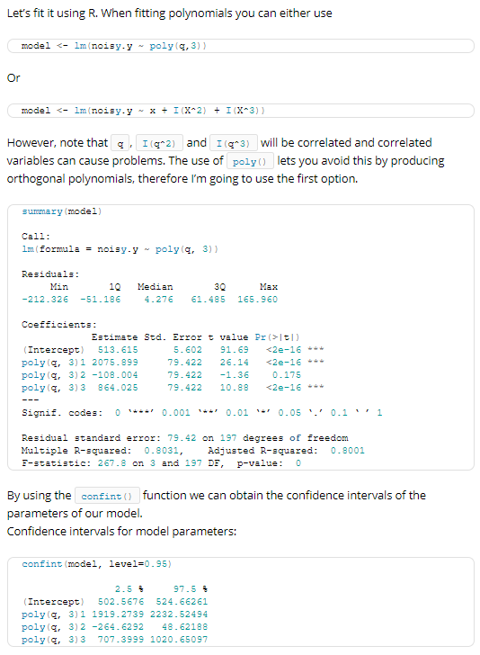

*图像3.2.1：多项式线型模型* [*Fitting Polynomial Regression in R*](https://www.r-bloggers.com/2015/09/fitting-polynomial-regression-in-r)

**备注**：[lm() breaks when using poly() with predictors set up as factors](https://stackoverflow.com/a/61410867/3806250)讲述`poly`无法分析多元`factor`而只能分析虚拟变量（0或1）。

$$Y = \beta_{0} + \beta_{1}X_{1} + \beta_{11}X^{2} + \beta_{111}X^{3}$$

*方程3.1.2：多元多项式线型模型*

##### 3.2.1.1.1 多元多项相互式正交模型

```r
## https://stackoverflow.com/a/24133767/3806250
num <- 2:5

mprf_list <- llply(num, function(i) {
    mprf = list(
        #p00 = lm(Profit ~
        #         poly(Date, degree = i, raw = FALSE) *
        #         poly(Bettor, degree = i, raw = FALSE) *
        #         poly(Turnover, degree = i, raw = FALSE) *
        #         poly(Won, degree = i, raw = FALSE) *
        #         poly(Cancelled, degree = i, raw = FALSE) *
        #         poly(Rebates, degree = i, raw = FALSE), smp2) %>% extractAIC,
        {p01 = lm(Profit ~
                     poly(Bettor, degree = i, raw = FALSE) *
                     poly(Turnover, degree = i, raw = FALSE) *
                     poly(Won, degree = i, raw = FALSE) *
                     poly(Cancelled, degree = i, raw = FALSE) *
                     poly(Rebates, degree = i, raw = FALSE), smp2) %>%
          extractAIC %>%
          as_tibble %>%
          t %>% as_tibble %>%
          dplyr::rename(df = V1, AIC = V2) %>%
          mutate(.md = paste0('mprf_p01'), degree = i, raw = FALSE) %>%
            dplyr::select(.md, degree, df, AIC);
        write_rds(p01, paste0('data/mprf', i, '_p01.rds'))},
        {p02 = lm(Profit ~
                     poly(Bettor, degree = i, raw = FALSE) *
                     poly(Turnover, degree = i, raw = FALSE) *
                     poly(Won, degree = i, raw = FALSE) *
                     poly(Cancelled, degree = i, raw = FALSE), smp2) %>%
          extractAIC %>%
          as_tibble %>%
          t %>% as_tibble %>%
          dplyr::rename(df = V1, AIC = V2) %>%
          mutate(.md = paste0('mprf_p02'), degree = i, raw = FALSE) %>%
            dplyr::select(.md, degree, df, AIC);
        write_rds(p02, paste0('data/mprf', i, '_p02.rds'))},
        {p03 = lm(Profit ~
                     poly(Bettor, degree = i, raw = FALSE) *
                     poly(Turnover, degree = i, raw = FALSE) *
                     poly(Won, degree = i, raw = FALSE) *
                     poly(Rebates, degree = i, raw = FALSE), smp2) %>%
          extractAIC %>%
          as_tibble %>%
          t %>% as_tibble %>%
          dplyr::rename(df = V1, AIC = V2) %>%
          mutate(.md = paste0('mprf_p03'), degree = i, raw = FALSE) %>%
            dplyr::select(.md, degree, df, AIC);
        write_rds(p03, paste0('data/mprf', i, '_p03.rds'))},
        {p04 = lm(Profit ~
                     poly(Bettor, degree = i, raw = FALSE) *
                     poly(Turnover, degree = i, raw = FALSE) *
                     poly(Cancelled, degree = i, raw = FALSE) *
                     poly(Rebates, degree = i, raw = FALSE), smp2) %>%
          extractAIC %>%
          as_tibble %>%
          t %>% as_tibble %>%
          dplyr::rename(df = V1, AIC = V2) %>%
          mutate(.md = paste0('mprf_p04'), degree = i, raw = FALSE) %>%
            dplyr::select(.md, degree, df, AIC);
        write_rds(p04, paste0('data/mprf', i, '_p04.rds'))},
        {p05 = lm(Profit ~
                     poly(Bettor, degree = i, raw = FALSE) *
                     poly(Won, degree = i, raw = FALSE) *
                     poly(Cancelled, degree = i, raw = FALSE) *
                     poly(Rebates, degree = i, raw = FALSE), smp2) %>%
          extractAIC %>%
          as_tibble %>%
          t %>% as_tibble %>%
          dplyr::rename(df = V1, AIC = V2) %>%
          mutate(.md = paste0('mprf_p05'), degree = i, raw = FALSE) %>%
            dplyr::select(.md, degree, df, AIC);
        write_rds(p05, paste0('data/mprf', i, '_p05.rds'))},
        {p06 = lm(Profit ~
                     poly(Turnover, degree = i, raw = FALSE) *
                     poly(Won, degree = i, raw = FALSE) *
                     poly(Cancelled, degree = i, raw = FALSE) *
                     poly(Rebates, degree = i, raw = FALSE), smp2) %>%
          extractAIC %>%
          as_tibble %>%
          t %>% as_tibble %>%
          dplyr::rename(df = V1, AIC = V2) %>%
          mutate(.md = paste0('mprf_p06'), degree = i, raw = FALSE) %>%
            dplyr::select(.md, degree, df, AIC);
        write_rds(p06, paste0('data/mprf', i, '_p06.rds'))},
        {p07 = lm(Profit ~
                     poly(Bettor, degree = i, raw = FALSE) *
                     poly(Turnover, degree = i, raw = FALSE) *
                     poly(Won, degree = i, raw = FALSE) *
                     poly(Cancelled, degree = i, raw = FALSE) *
                     poly(Rebates, degree = i, raw = FALSE), smp2) %>%
          extractAIC %>%
          as_tibble %>%
          t %>% as_tibble %>%
          dplyr::rename(df = V1, AIC = V2) %>%
          mutate(.md = paste0('mprf_p07'), degree = i, raw = FALSE) %>%
            dplyr::select(.md, degree, df, AIC);
        write_rds(p07, paste0('data/mprf', i, '_p07.rds'))},
        {p08 = lm(Profit ~
                     poly(Bettor, degree = i, raw = FALSE) *
                     poly(Turnover, degree = i, raw = FALSE) *
                     poly(Won, degree = i, raw = FALSE), smp2) %>%
          extractAIC %>%
          as_tibble %>%
          t %>% as_tibble %>%
          dplyr::rename(df = V1, AIC = V2) %>%
          mutate(.md = paste0('mprf_p08'), degree = i, raw = FALSE) %>%
            dplyr::select(.md, degree, df, AIC);
        write_rds(p08, paste0('data/mprf', i, '_p08.rds'))},
        {p09 = lm(Profit ~
                     poly(Bettor, degree = i, raw = FALSE) *
                     poly(Turnover, degree = i, raw = FALSE) *
                     poly(Rebates, degree = i, raw = FALSE), smp2) %>%
          extractAIC %>%
          as_tibble %>%
          t %>% as_tibble %>%
          dplyr::rename(df = V1, AIC = V2) %>%
          mutate(.md = paste0('mprf_p09'), degree = i, raw = FALSE) %>%
            dplyr::select(.md, degree, df, AIC);
        write_rds(p09, paste0('data/mprf', i, '_p09.rds'))},
        {p10 = lm(Profit ~
                     poly(Won, degree = i, raw = FALSE) *
                     poly(Cancelled, degree = i, raw = FALSE) *
                     poly(Rebates, degree = i, raw = FALSE), smp2) %>%
          extractAIC %>%
          as_tibble %>%
          t %>% as_tibble %>%
          dplyr::rename(df = V1, AIC = V2) %>%
          mutate(.md = paste0('mprf_p10'), degree = i, raw = FALSE) %>%
            dplyr::select(.md, degree, df, AIC);
        write_rds(p10, paste0('data/mprf', i, '_p10.rds'))},
        {p11 = lm(Profit ~
                     poly(Bettor, degree = i, raw = FALSE) *
                     poly(Turnover, degree = i, raw = FALSE) *
                     poly(Cancelled, degree = i, raw = FALSE), smp2) %>%
          extractAIC %>%
          as_tibble %>%
          t %>% as_tibble %>%
          dplyr::rename(df = V1, AIC = V2) %>%
          mutate(.md = paste0('mprf_p11'), degree = i, raw = FALSE) %>%
            dplyr::select(.md, degree, df, AIC);
        write_rds(p11, paste0('data/mprf', i, '_p11.rds'))},
        {p12 = lm(Profit ~
                     poly(Bettor, degree = i, raw = FALSE) *
                     poly(Won, degree = i, raw = FALSE) *
                     poly(Rebates, degree = i, raw = FALSE), smp2) %>%
          extractAIC %>%
          as_tibble %>%
          t %>% as_tibble %>%
          dplyr::rename(df = V1, AIC = V2) %>%
          mutate(.md = paste0('mprf_p12'), degree = i, raw = FALSE) %>%
            dplyr::select(.md, degree, df, AIC);
        write_rds(p12, paste0('data/mprf', i, '_p12.rds'))},
        {p13 = lm(Profit ~
                     poly(Bettor, degree = i, raw = FALSE) *
                     poly(Won, degree = i, raw = FALSE) *
                     poly(Cancelled, degree = i, raw = FALSE), smp2) %>%
          extractAIC %>%
          as_tibble %>%
          t %>% as_tibble %>%
          dplyr::rename(df = V1, AIC = V2) %>%
          mutate(.md = paste0('mprf_p13'), degree = i, raw = FALSE) %>%
            dplyr::select(.md, degree, df, AIC);
        write_rds(p13, paste0('data/mprf', i, '_p13.rds'))},
        {p14 = lm(Profit ~
                     poly(Turnover, degree = i, raw = FALSE) *
                     poly(Won, degree = i, raw = FALSE) *
                     poly(Rebates, degree = i, raw = FALSE), smp2) %>%
          extractAIC %>%
          as_tibble %>%
          t %>% as_tibble %>%
          dplyr::rename(df = V1, AIC = V2) %>%
          mutate(.md = paste0('mprf_p14'), degree = i, raw = FALSE) %>%
            dplyr::select(.md, degree, df, AIC);
        write_rds(p14, paste0('data/mprf', i, '_p14.rds'))},
        {p15 = lm(Profit ~
                     poly(Turnover, degree = i, raw = FALSE) *
                     poly(Cancelled, degree = i, raw = FALSE) *
                     poly(Rebates, degree = i, raw = FALSE), smp2) %>%
          extractAIC %>%
          as_tibble %>%
          t %>% as_tibble %>%
          dplyr::rename(df = V1, AIC = V2) %>%
          mutate(.md = paste0('mprf_p15'), degree = i, raw = FALSE) %>%
            dplyr::select(.md, degree, df, AIC);
        write_rds(p15, paste0('data/mprf', i, '_p15.rds'))},
        {p16 = lm(Profit ~
                     poly(Turnover, degree = i, raw = FALSE) *
                     poly(Won, degree = i, raw = FALSE) *
                     poly(Rebates, degree = i, raw = FALSE), smp2) %>%
          extractAIC %>%
          as_tibble %>%
          t %>% as_tibble %>%
          dplyr::rename(df = V1, AIC = V2) %>%
          mutate(.md = paste0('mprf_p16'), degree = i, raw = FALSE) %>%
            dplyr::select(.md, degree, df, AIC);
        write_rds(p16, paste0('data/mprf', i, '_p16.rds'))},
        {p17 = lm(Profit ~
                     poly(Won, degree = i, raw = FALSE) *
                     poly(Cancelled, degree = i, raw = FALSE) *
                     poly(Rebates, degree = i, raw = FALSE), smp2) %>%
          extractAIC %>%
          as_tibble %>%
          t %>% as_tibble %>%
          dplyr::rename(df = V1, AIC = V2) %>%
          mutate(.md = paste0('mprf_p17'), degree = i, raw = FALSE) %>%
            dplyr::select(.md, degree, df, AIC);
        write_rds(p17, paste0('data/mprf', i, '_p17.rds'))},
        {p18 = lm(Profit ~
                     poly(Bettor, degree = i, raw = FALSE) *
                     poly(Turnover, degree = i, raw = FALSE) *
                     poly(Won, degree = i, raw = FALSE) *
                     poly(Cancelled, degree = i, raw = FALSE), smp2) %>%
          extractAIC %>%
          as_tibble %>%
          t %>% as_tibble %>%
          dplyr::rename(df = V1, AIC = V2) %>%
          mutate(.md = paste0('mprf_p18'), degree = i, raw = FALSE) %>%
            dplyr::select(.md, degree, df, AIC);
        write_rds(p18, paste0('data/mprf', i, '_p18.rds'))},
        {p19 = lm(Profit ~
                     poly(Bettor, degree = i, raw = FALSE) *
                     poly(Turnover, degree = i, raw = FALSE) *
                     poly(Won, degree = i, raw = FALSE) *
                     poly(Rebates, degree = i, raw = FALSE), smp2) %>%
          extractAIC %>%
          as_tibble %>%
          t %>% as_tibble %>%
          dplyr::rename(df = V1, AIC = V2) %>%
          mutate(.md = paste0('mprf_p19'), degree = i, raw = FALSE) %>%
            dplyr::select(.md, degree, df, AIC);
        write_rds(p19, paste0('data/mprf', i, '_p19.rds'))},
        {p20 = lm(Profit ~
                     poly(Bettor, degree = i, raw = FALSE) *
                     poly(Turnover, degree = i, raw = FALSE) *
                     poly(Cancelled, degree = i, raw = FALSE) *
                     poly(Rebates, degree = i, raw = FALSE), smp2) %>%
          extractAIC %>%
          as_tibble %>%
          t %>% as_tibble %>%
          dplyr::rename(df = V1, AIC = V2) %>%
          mutate(.md = paste0('mprf_p20'), degree = i, raw = FALSE) %>%
            dplyr::select(.md, degree, df, AIC);
        write_rds(p20, paste0('data/mprf', i, '_p20.rds'))},
        {p21 = lm(Profit ~
                     poly(Bettor, degree = i, raw = FALSE) *
                     poly(Turnover, degree = i, raw = FALSE) *
                     poly(Won, degree = i, raw = FALSE) *
```

```r
                     poly(Cancelled, degree = i, raw = FALSE) *
                     poly(Rebates, degree = i, raw = FALSE), smp2) %>%
          extractAIC %>%
          as_tibble %>%
          t %>% as_tibble %>%
          dplyr::rename(df = V1, AIC = V2) %>%
          mutate(.md = paste0('mprf_p21'), degree = i, raw = FALSE) %>%
            dplyr::select(.md, degree, df, AIC);
        write_rds(p21, paste0('data/mprf', i, '_p21.rds'))},
        {p22 = lm(Profit ~
                     poly(Turnover, degree = i, raw = FALSE) *
                     poly(Won, degree = i, raw = FALSE) *
                     poly(Cancelled, degree = i, raw = FALSE) *
                     poly(Rebates, degree = i, raw = FALSE), smp2) %>%
          extractAIC %>%
          as_tibble %>%
          t %>% as_tibble %>%
          dplyr::rename(df = V1, AIC = V2) %>%
          mutate(.md = paste0('mprf_p22'), degree = i, raw = FALSE) %>%
            dplyr::select(.md, degree, df, AIC);
        write_rds(p22, paste0('data/mprf', i, '_p22.rds'))}
    ) %>%
        ldply %>%
        as_tibble

    ## save files, easier to read.
    #write_rds(mprf, paste0('data/mprf', i, '.rds'))
})
```

##### 3.2.1.1.2 多元多项相互式原始模型

```r
## https://stackoverflow.com/a/24133767/3806250
num <- 2:5

mprt_list <- llply(num, function(i) {
    mprt = list(
        #p00 = lm(Profit ~
        #         poly(Date, degree = i, raw = TRUE) *
        #         poly(Bettor, degree = i, raw = TRUE) *
        #         poly(Turnover, degree = i, raw = TRUE) *
        #         poly(Won, degree = i, raw = TRUE) *
        #         poly(Cancelled, degree = i, raw = TRUE) *
        #         poly(Rebates, degree = i, raw = TRUE), smp2) %>% extractAIC,
        {p01 = lm(Profit ~
                     poly(Bettor, degree = i, raw = TRUE) *
                     poly(Turnover, degree = i, raw = TRUE) *
                     poly(Won, degree = i, raw = TRUE) *
                     poly(Cancelled, degree = i, raw = TRUE) *
                     poly(Rebates, degree = i, raw = TRUE), smp2) %>%
          extractAIC %>%
          as_tibble %>%
          t %>% as_tibble %>%
          dplyr::rename(df = V1, AIC = V2) %>%
          mutate(.md = paste0('mprt_p01'), degree = i, raw = TRUE) %>%
            dplyr::select(.md, degree, df, AIC);
        write_rds(p01, paste0('data/mprt', i, '_p01.rds'))},
        {p02 = lm(Profit ~
                     poly(Bettor, degree = i, raw = TRUE) *
                     poly(Turnover, degree = i, raw = TRUE) *
                     poly(Won, degree = i, raw = TRUE) *
                     poly(Cancelled, degree = i, raw = TRUE), smp2) %>%
          extractAIC %>%
          as_tibble %>%
          t %>% as_tibble %>%
          dplyr::rename(df = V1, AIC = V2) %>%
          mutate(.md = paste0('mprt_p02'), degree = i, raw = TRUE) %>%
            dplyr::select(.md, degree, df, AIC);
        write_rds(p02, paste0('data/mprt', i, '_p02.rds'))},
        {p03 = lm(Profit ~
                     poly(Bettor, degree = i, raw = TRUE) *
                     poly(Turnover, degree = i, raw = TRUE) *
                     poly(Won, degree = i, raw = TRUE) *
                     poly(Rebates, degree = i, raw = TRUE), smp2) %>%
          extractAIC %>%
          as_tibble %>%
          t %>% as_tibble %>%
          dplyr::rename(df = V1, AIC = V2) %>%
          mutate(.md = paste0('mprt_p03'), degree = i, raw = TRUE) %>%
            dplyr::select(.md, degree, df, AIC);
        write_rds(p03, paste0('data/mprt', i, '_p03.rds'))},
        {p04 = lm(Profit ~
                     poly(Bettor, degree = i, raw = TRUE) *
                     poly(Turnover, degree = i, raw = TRUE) *
                     poly(Cancelled, degree = i, raw = TRUE) *
                     poly(Rebates, degree = i, raw = TRUE), smp2) %>%
          extractAIC %>%
          as_tibble %>%
          t %>% as_tibble %>%
          dplyr::rename(df = V1, AIC = V2) %>%
          mutate(.md = paste0('mprt_p04'), degree = i, raw = TRUE) %>%
            dplyr::select(.md, degree, df, AIC);
        write_rds(p04, paste0('data/mprt', i, '_p04.rds'))},
        {p05 = lm(Profit ~
                     poly(Bettor, degree = i, raw = TRUE) *
                     poly(Won, degree = i, raw = TRUE) *
                     poly(Cancelled, degree = i, raw = TRUE) *
                     poly(Rebates, degree = i, raw = TRUE), smp2) %>%
          extractAIC %>%
          as_tibble %>%
          t %>% as_tibble %>%
          dplyr::rename(df = V1, AIC = V2) %>%
          mutate(.md = paste0('mprt_p05'), degree = i, raw = TRUE) %>%
            dplyr::select(.md, degree, df, AIC);
        write_rds(p05, paste0('data/mprt', i, '_p05.rds'))},
        {p06 = lm(Profit ~
                     poly(Turnover, degree = i, raw = TRUE) *
                     poly(Won, degree = i, raw = TRUE) *
                     poly(Cancelled, degree = i, raw = TRUE) *
                     poly(Rebates, degree = i, raw = TRUE), smp2) %>%
          extractAIC %>%
          as_tibble %>%
          t %>% as_tibble %>%
          dplyr::rename(df = V1, AIC = V2) %>%
          mutate(.md = paste0('mprt_p06'), degree = i, raw = TRUE) %>%
            dplyr::select(.md, degree, df, AIC);
        write_rds(p06, paste0('data/mprt', i, '_p06.rds'))},
        {p07 = lm(Profit ~
                     poly(Bettor, degree = i, raw = TRUE) *
                     poly(Turnover, degree = i, raw = TRUE) *
                     poly(Won, degree = i, raw = TRUE) *
                     poly(Cancelled, degree = i, raw = TRUE) *
                     poly(Rebates, degree = i, raw = TRUE), smp2) %>%
          extractAIC %>%
          as_tibble %>%
          t %>% as_tibble %>%
          dplyr::rename(df = V1, AIC = V2) %>%
          mutate(.md = paste0('mprt_p07'), degree = i, raw = TRUE) %>%
            dplyr::select(.md, degree, df, AIC);
        write_rds(p07, paste0('data/mprt', i, '_p07.rds'))},
        {p08 = lm(Profit ~
                     poly(Bettor, degree = i, raw = TRUE) *
                     poly(Turnover, degree = i, raw = TRUE) *
                     poly(Won, degree = i, raw = TRUE), smp2) %>%
          extractAIC %>%
          as_tibble %>%
          t %>% as_tibble %>%
          dplyr::rename(df = V1, AIC = V2) %>%
          mutate(.md = paste0('mprt_p08'), degree = i, raw = TRUE) %>%
            dplyr::select(.md, degree, df, AIC);
        write_rds(p08, paste0('data/mprt', i, '_p08.rds'))},
        {p09 = lm(Profit ~
                     poly(Bettor, degree = i, raw = TRUE) *
                     poly(Turnover, degree = i, raw = TRUE) *
                     poly(Rebates, degree = i, raw = TRUE), smp2) %>%
          extractAIC %>%
          as_tibble %>%
          t %>% as_tibble %>%
          dplyr::rename(df = V1, AIC = V2) %>%
          mutate(.md = paste0('mprt_p09'), degree = i, raw = TRUE) %>%
            dplyr::select(.md, degree, df, AIC);
        write_rds(p09, paste0('data/mprt', i, '_p09.rds'))},
        {p10 = lm(Profit ~
                     poly(Won, degree = i, raw = TRUE) *
                     poly(Cancelled, degree = i, raw = TRUE) *
                     poly(Rebates, degree = i, raw = TRUE), smp2) %>%
          extractAIC %>%
          as_tibble %>%
          t %>% as_tibble %>%
          dplyr::rename(df = V1, AIC = V2) %>%
          mutate(.md = paste0('mprt_p10'), degree = i, raw = TRUE) %>%
            dplyr::select(.md, degree, df, AIC);
        write_rds(p10, paste0('data/mprt', i, '_p10.rds'))},
        {p11 = lm(Profit ~
                     poly(Bettor, degree = i, raw = TRUE) *
                     poly(Turnover, degree = i, raw = TRUE) *
                     poly(Cancelled, degree = i, raw = TRUE), smp2) %>%
          extractAIC %>%
          as_tibble %>%
          t %>% as_tibble %>%
          dplyr::rename(df = V1, AIC = V2) %>%
          mutate(.md = paste0('mprt_p11'), degree = i, raw = TRUE) %>%
            dplyr::select(.md, degree, df, AIC);
        write_rds(p11, paste0('data/mprt', i, '_p11.rds'))},
        {p12 = lm(Profit ~
                     poly(Bettor, degree = i, raw = TRUE) *
                     poly(Won, degree = i, raw = TRUE) *
                     poly(Rebates, degree = i, raw = TRUE), smp2) %>%
          extractAIC %>%
          as_tibble %>%
          t %>% as_tibble %>%
          dplyr::rename(df = V1, AIC = V2) %>%
          mutate(.md = paste0('mprt_p12'), degree = i, raw = TRUE) %>%
            dplyr::select(.md, degree, df, AIC);
        write_rds(p12, paste0('data/mprt', i, '_p12.rds'))},
        {p13 = lm(Profit ~
                     poly(Bettor, degree = i, raw = TRUE) *
                     poly(Won, degree = i, raw = TRUE) *
                     poly(Cancelled, degree = i, raw = TRUE), smp2) %>%
          extractAIC %>%
          as_tibble %>%
          t %>% as_tibble %>%
          dplyr::rename(df = V1, AIC = V2) %>%
          mutate(.md = paste0('mprt_p13'), degree = i, raw = TRUE) %>%
            dplyr::select(.md, degree, df, AIC);
        write_rds(p13, paste0('data/mprt', i, '_p13.rds'))},
        {p14 = lm(Profit ~
                     poly(Turnover, degree = i, raw = TRUE) *
                     poly(Won, degree = i, raw = TRUE) *
                     poly(Rebates, degree = i, raw = TRUE), smp2) %>%
          extractAIC %>%
          as_tibble %>%
          t %>% as_tibble %>%
          dplyr::rename(df = V1, AIC = V2) %>%
          mutate(.md = paste0('mprt_p14'), degree = i, raw = TRUE) %>%
            dplyr::select(.md, degree, df, AIC);
        write_rds(p14, paste0('data/mprt', i, '_p14.rds'))},
        {p15 = lm(Profit ~
                     poly(Turnover, degree = i, raw = TRUE) *
                     poly(Cancelled, degree = i, raw = TRUE) *
                     poly(Rebates, degree = i, raw = TRUE), smp2) %>%
          extractAIC %>%
          as_tibble %>%
          t %>% as_tibble %>%
          dplyr::rename(df = V1, AIC = V2) %>%
          mutate(.md = paste0('mprt_p15'), degree = i, raw = TRUE) %>%
            dplyr::select(.md, degree, df, AIC);
        write_rds(p15, paste0('data/mprt', i, '_p15.rds'))},
        {p16 = lm(Profit ~
                     poly(Turnover, degree = i, raw = TRUE) *
                     poly(Won, degree = i, raw = TRUE) *
                     poly(Rebates, degree = i, raw = TRUE), smp2) %>%
          extractAIC %>%
          as_tibble %>%
          t %>% as_tibble %>%
          dplyr::rename(df = V1, AIC = V2) %>%
          mutate(.md = paste0('mprt_p16'), degree = i, raw = TRUE) %>%
            dplyr::select(.md, degree, df, AIC);
        write_rds(p16, paste0('data/mprt', i, '_p16.rds'))},
        {p17 = lm(Profit ~
                     poly(Won, degree = i, raw = TRUE) *
                     poly(Cancelled, degree = i, raw = TRUE) *
                     poly(Rebates, degree = i, raw = TRUE), smp2) %>%
          extractAIC %>%
          as_tibble %>%
          t %>% as_tibble %>%
          dplyr::rename(df = V1, AIC = V2) %>%
          mutate(.md = paste0('mprt_p17'), degree = i, raw = TRUE) %>%
            dplyr::select(.md, degree, df, AIC);
        write_rds(p17, paste0('data/mprt', i, '_p17.rds'))},
        {p18 = lm(Profit ~
                     poly(Bettor, degree = i, raw = TRUE) *
                     poly(Turnover, degree = i, raw = TRUE) *
                     poly(Won, degree = i, raw = TRUE) *
                     poly(Cancelled, degree = i, raw = TRUE), smp2) %>%
          extractAIC %>%
          as_tibble %>%
          t %>% as_tibble %>%
          dplyr::rename(df = V1, AIC = V2) %>%
          mutate(.md = paste0('mprt_p18'), degree = i, raw = TRUE) %>%
            dplyr::select(.md, degree, df, AIC);
        write_rds(p18, paste0('data/mprt', i, '_p18.rds'))},
        {p19 = lm(Profit ~
                     poly(Bettor, degree = i, raw = TRUE) *
                     poly(Turnover, degree = i, raw = TRUE) *
                     poly(Won, degree = i, raw = TRUE) *
                     poly(Rebates, degree = i, raw = TRUE), smp2) %>%
          extractAIC %>%
          as_tibble %>%
          t %>% as_tibble %>%
          dplyr::rename(df = V1, AIC = V2) %>%
          mutate(.md = paste0('mprt_p19'), degree = i, raw = TRUE) %>%
            dplyr::select(.md, degree, df, AIC);
        write_rds(p19, paste0('data/mprt', i, '_p19.rds'))},
        {p20 = lm(Profit ~
                     poly(Bettor, degree = i, raw = TRUE) *
                     poly(Turnover, degree = i, raw = TRUE) *
                     poly(Cancelled, degree = i, raw = TRUE) *
                     poly(Rebates, degree = i, raw = TRUE), smp2) %>%
          extractAIC %>%
          as_tibble %>%
          t %>% as_tibble %>%
          dplyr::rename(df = V1, AIC = V2) %>%
          mutate(.md = paste0('mprt_p20'), degree = i, raw = TRUE) %>%
            dplyr::select(.md, degree, df, AIC);
        write_rds(p20, paste0('data/mprt', i, '_p20.rds'))},
        {p21 = lm(Profit ~
                     poly(Bettor, degree = i, raw = TRUE) *
                     poly(Turnover, degree = i, raw = TRUE) *
                     poly(Won, degree = i, raw = TRUE) *
                     poly(Cancelled, degree = i, raw = TRUE) *
                     poly(Rebates, degree = i, raw = TRUE), smp2) %>%
```

```r
          extractAIC %>%
          as_tibble %>%
          t %>% as_tibble %>%
          dplyr::rename(df = V1, AIC = V2) %>%
          mutate(.md = paste0('mprt_p21'), degree = i, raw = TRUE) %>%
            dplyr::select(.md, degree, df, AIC);
        write_rds(p21, paste0('data/mprt', i, '_p21.rds'))},
        {p22 = lm(Profit ~
                     poly(Turnover, degree = i, raw = TRUE) *
                     poly(Won, degree = i, raw = TRUE) *
                     poly(Cancelled, degree = i, raw = TRUE) *
                     poly(Rebates, degree = i, raw = TRUE), smp2) %>%
          extractAIC %>%
          as_tibble %>%
          t %>% as_tibble %>%
          dplyr::rename(df = V1, AIC = V2) %>%
          mutate(.md = paste0('mprt_p22'), degree = i, raw = TRUE) %>%
            dplyr::select(.md, degree, df, AIC);
        write_rds(p22, paste0('data/mprt', i, '_p22.rds'))}
    ) %>%
        ldply %>%
        as_tibble

    ## save files, easier to read.
    #write_rds(mprt, paste0('data/mprt', i, '.rds'))
})
```

#### 3.2.1.2 多元多项相互式程度最优化

以下文章聊及多元多项相互式线型模型程度最优化。

```
To get a third order polynomial in x (x^3), you can do

lm(y ~ x + I(x^2) + I(x^3))
or

lm(y ~ poly(x, 3, raw=TRUE))
You could fit a 10th order polynomial and get a near-perfect fit, but should you?

EDIT: poly(x, 3) is probably a better choice (see @hadley below).
```

*出处：*[*Fitting polynomial model to data in R*](https://stackoverflow.com/a/3822706/3806250)

```
But what I want to say is that a polynomial of more than 3-5 degree is never useful! The critical reason is the Runge's phenomenon. In terms of statistical terminology: a high-order polynomial always badly overfits data!. Don't naively think that because orthogonal polynomials are numerically more stable than raw polynomials, Runge's effect can be eliminated. No, a polynomial of degree k forms a vector space, so whatever basis you use for representation, they have the same span!
```

*出处：*[*High (or very high) order polynomial regression in R (or alternatives?)*](https://stackoverflow.com/a/39803843/3806250)

```
Deciding on a degree
In performing a polynomial regression we must decide on the degree of the polynomial to use. One way to do this is by using hypothesis tests. We now fit models ranging from linear to a degree-5 polynomial and seek to determine the simplest model which is sufficient to explain the relationship between wage and age.

We can do this using the anova() function, which performs an analysis of variance (ANOVA, using an F-test) in order to test the null hypothesis that a model  M1  is sufficient to explain the data against the alternative hypothesis that a more complex model  M2  is required. In order to use the anova() function,  M1  and  M2  must be nested models: the predictors in  M1  must be a subset of the predictors in  M2 . In this case, we fit five different models and sequentially compare the simpler model to the more complex model:

fit_1 = lm(wage~age, data = Wage)
fit_2 = lm(wage~poly(age,2), data = Wage)
fit_3 = lm(wage~poly(age,3), data = Wage)
fit_4 = lm(wage~poly(age,4), data = Wage)
fit_5 = lm(wage~poly(age,5), data = Wage)
print(anova(fit_1,fit_2,fit_3,fit_4,fit_5))
```

[*7.8.1 Polynomial Regression and Step Functions7.8.1 Polynomial Regression and Step Functions*](http://www.science.smith.edu/~jcrouser/SDS293/labs/lab12-r.html#Deciding-on-a-degree)

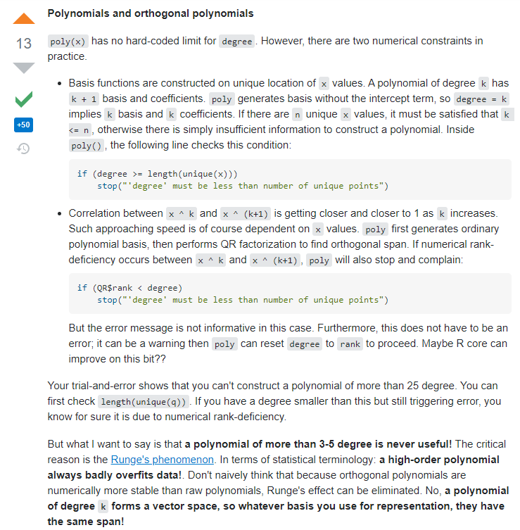

*图像3.2.2a：分层多项式线型模型* [*High (or very high) order polynomial regression in R (or alternatives?)*](https://stackoverflow.com/a/39803843/3806250)

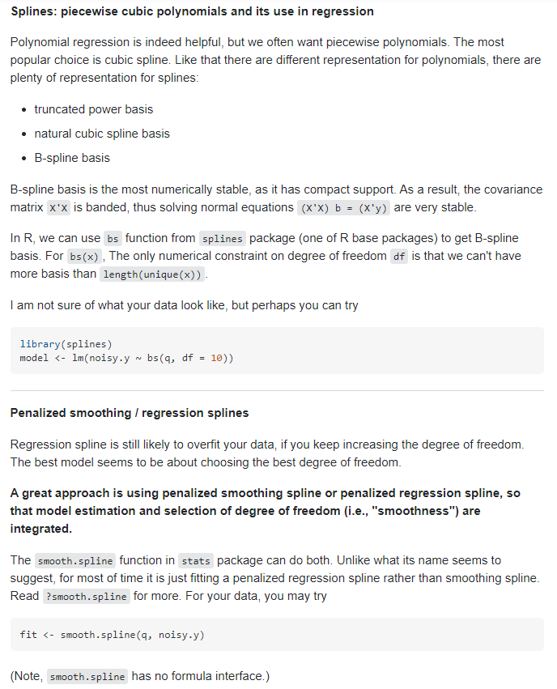

*图像3.2.2b：分层多项式线型模型* [*High (or very high) order polynomial regression in R (or alternatives?)*](https://stackoverflow.com/a/39803843/3806250)

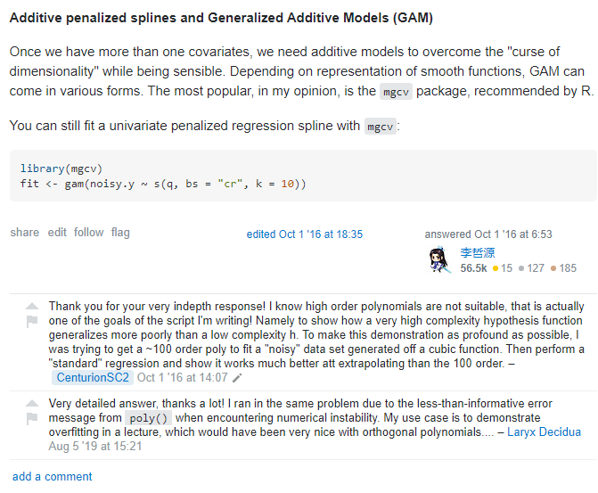

*图像3.2.2c：分层多项式线型模型* [*High (or very high) order polynomial regression in R (or alternatives?)*](https://stackoverflow.com/a/39803843/3806250)

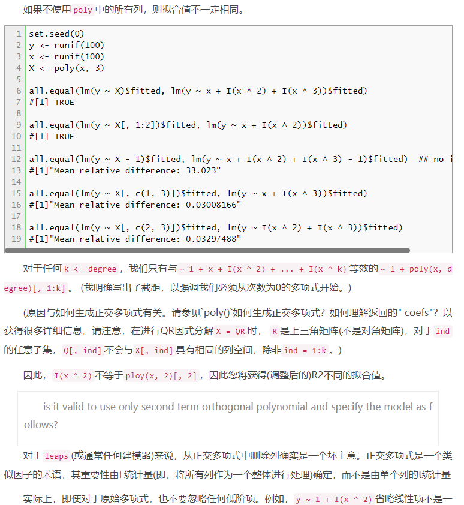

*图像3.2.3a：拟合由`leaps :: regsubsets`选择的多项式回归模型* [*关于r：拟合由`leaps :: regsubsets`选择的多项式回归模型*](https://www.codenong.com/51223897)

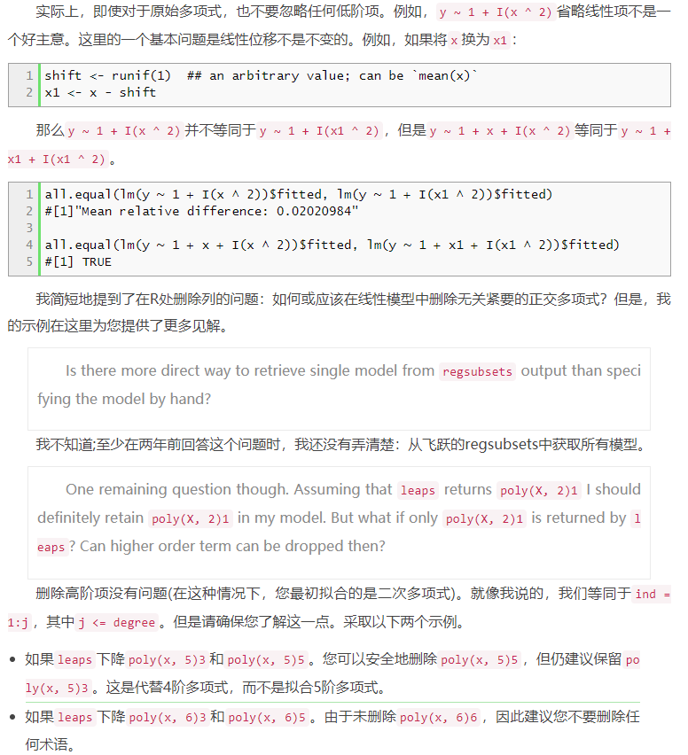

*图像3.2.3b：拟合由`leaps :: regsubsets`选择的多项式回归模型* [*关于r：拟合由`leaps :: regsubsets`选择的多项式回归模型*](https://www.codenong.com/51223897)

```r
mdp <- dir('data', pattern = '^mp') %>%
    ldply(., function(x) {
        read_rds(paste0('data/', x))
    }) %>%
    as_tibble
```

```r
mdp %>%
  mutate(
    df = color_tile('#2a52be', 'white')(df), #colbalt
    AIC = ifelse(
      rank(AIC) <= 3,
      cell_spec(
        paste0(round(AIC, 2), ' (rank: ', sprintf('%1.f', rank(AIC)), ')'),
        'html', color = 'darkgoldenrod', bold = T),
      cell_spec(
        paste0(round(AIC, 2), ' (rank: ', sprintf('%1.f', rank(AIC)), ')'),
        'html', color = 'grey', italic = T))) %>%
  kbl('html', caption = '分组最优模型', escape = F, align = c('c', 'r', 'r')) %>%
  kable_styling(
    bootstrap_options = c('striped', 'hover', 'condensed', 'responsive')) %>%
  kable_material() %>%
  pack_rows('多项式回归 2', 1, 22, label_row_css = 'background-color: #666; color: #fff;') %>%
  pack_rows('多项式回归 3', 23, 44, label_row_css = 'background-color: #666; color: #fff;') %>%
  pack_rows('多项式回归 4', 45, 65, label_row_css = 'background-color: #666; color: #fff;') %>%
  pack_rows('多项式回归 5', 67, 88, label_row_css = 'background-color: #666; color: #fff;') %>%
  pack_rows('多项式正交回归 2', 89, 110, label_row_css = 'background-color: #666; color: #fff;') %>%
  pack_rows('多项式正交回归 3', 111, 132, label_row_css = 'background-color: #666; color: #fff;') %>%
  pack_rows('多项式正交回归 4', 133, 154, label_row_css = 'background-color: #666; color: #fff;') %>%
  pack_rows('多项式正交回归 5', 155, 176, label_row_css = 'background-color: #666; color: #fff;') %>%
  pack_rows('多项式原始回归 2', 177, 198, label_row_css = 'background-color: #666; color: #fff;') %>%
  pack_rows('多项式原始回归 3', 199, 220, label_row_css = 'background-color: #666; color: #fff;') %>%
  pack_rows('多项式原始回归 4', 221, 242, label_row_css = 'background-color: #666; color: #fff;') %>%
  pack_rows('多项式原始回归 5', 243, 264, label_row_css = 'background-color: #666; color: #fff;') %>%
  scroll_box(height = '400px')
```

分组最优模型

| .id | df | AIC | .md | degree |
| --- | --- | --- | --- | --- |
| **多项式回归 2** |  |  |  |  |
| p01 | 163 | -47047.18 (rank: 58) | NA | NA |
| p02 | 80 | 48874.2 (rank: 136) | NA | NA |
| p03 | 80 | -47016 (rank: 88) | NA | NA |
| p04 | 81 | 71206.9 (rank: 218) | NA | NA |
| p05 | 81 | 71583.33 (rank: 222) | NA | NA |
| p06 | 80 | -47013.76 (rank: 94) | NA | NA |
| p07 | 163 | -47047.18 (rank: 58) | NA | NA |
| p08 | 27 | 52413.59 (rank: 144) | NA | NA |
| p09 | 27 | 74533.99 (rank: 254) | NA | NA |
| p10 | 27 | 74923.73 (rank: 262) | NA | NA |
| p11 | 27 | 74027.3 (rank: 244) | NA | NA |
| p12 | 27 | 74847.88 (rank: 258) | NA | NA |
| p13 | 27 | 74351.92 (rank: 248) | NA | NA |
| p14 | 27 | -46979.4 (rank: 106) | NA | NA |
| p15 | 27 | 74470.37 (rank: 250) | NA | NA |
| p16 | 27 | -46979.4 (rank: 106) | NA | NA |
| p17 | 27 | 74923.73 (rank: 262) | NA | NA |
| p18 | 80 | 48874.2 (rank: 136) | NA | NA |
| p19 | 80 | -47016 (rank: 88) | NA | NA |
| p20 | 81 | 71206.9 (rank: 218) | NA | NA |
| p21 | 163 | -47047.18 (rank: 58) | NA | NA |
| p22 | 80 | -47013.76 (rank: 94) | NA | NA |
| **多项式回归 3** |  |  |  |  |
| p01 | 216 | -47089.09 (rank: 42) | NA | NA |
| p02 | 136 | 43914.19 (rank: 126) | NA | NA |
| p03 | 147 | -47101.64 (rank: 30) | NA | NA |
| p04 | 153 | 69851 (rank: 174) | NA | NA |
| p05 | 154 | 69771.47 (rank: 170) | NA | NA |
| p06 | 130 | -47031.72 (rank: 72) | NA | NA |

[output cut: 246 more lines]

*图表3.2.1.1：分组最优模型*

```r
mdp %>%
  arrange(AIC) %>%
  mutate(
    df = color_tile('#2a52be', 'white')(df), #colbalt
    AIC = ifelse(
      rank(AIC) <= 3,
      cell_spec(
        paste0(round(AIC, 2), ' (rank: ', sprintf('%1.f', rank(AIC)), ')'),
        'html', color = 'darkgoldenrod', bold = T),
      cell_spec(
        paste0(round(AIC, 2), ' (rank: ', sprintf('%1.f', rank(AIC)), ')'),
        'html', color = 'grey', italic = T))) %>%
  kbl('html', caption = '最优模型排行榜', escape = F, align = c('c', 'r', 'r')) %>%
  kable_styling(
    bootstrap_options = c('striped', 'hover', 'condensed', 'responsive')) %>%
  kable_material() %>%
  scroll_box(height = '400px')
```

最优模型排行榜

| .id | df | AIC | .md | degree |
| --- | --- | --- | --- | --- |
| NA | 477 | -47326.66 (rank: 2) | mprf_p01 | 5 |
| NA | 477 | -47326.66 (rank: 2) | mprf_p07 | 5 |
| NA | 477 | -47326.66 (rank: 2) | mprf_p21 | 5 |
| NA | 401 | -47228.15 (rank: 5) | mprf_p01 | 4 |
| NA | 401 | -47228.15 (rank: 5) | mprf_p07 | 4 |
| NA | 401 | -47228.15 (rank: 5) | mprf_p21 | 4 |
| NA | 312 | -47206.52 (rank: 8) | mprf_p03 | 5 |
| NA | 312 | -47206.52 (rank: 8) | mprf_p19 | 5 |
| NA | 316 | -47175.22 (rank: 10) | mprf_p01 | 3 |
| NA | 316 | -47175.22 (rank: 10) | mprf_p07 | 3 |
| NA | 316 | -47175.22 (rank: 10) | mprf_p21 | 3 |
| p01 | 288 | -47154.07 (rank: 14) | NA | NA |
| p07 | 288 | -47154.07 (rank: 14) | NA | NA |
| p21 | 288 | -47154.07 (rank: 14) | NA | NA |
| NA | 288 | -47154.07 (rank: 14) | mprt_p01 | 5 |
| NA | 288 | -47154.07 (rank: 14) | mprt_p07 | 5 |
| NA | 288 | -47154.07 (rank: 14) | mprt_p21 | 5 |
| NA | 260 | -47152.41 (rank: 18) | mprf_p03 | 4 |
| NA | 260 | -47152.41 (rank: 18) | mprf_p19 | 4 |
| p01 | 238 | -47145.04 (rank: 22) | NA | NA |
| p07 | 238 | -47145.04 (rank: 22) | NA | NA |
| p21 | 238 | -47145.04 (rank: 22) | NA | NA |
| NA | 238 | -47145.04 (rank: 22) | mprt_p01 | 4 |
| NA | 238 | -47145.04 (rank: 22) | mprt_p07 | 4 |
| NA | 238 | -47145.04 (rank: 22) | mprt_p21 | 4 |
| NA | 196 | -47107.79 (rank: 26) | mprf_p03 | 3 |
| NA | 196 | -47107.79 (rank: 26) | mprf_p19 | 3 |
| p03 | 147 | -47101.64 (rank: 30) | NA | NA |
| p19 | 147 | -47101.64 (rank: 30) | NA | NA |
| NA | 147 | -47101.64 (rank: 30) | mprt_p03 | 3 |

[output cut: 234 more lines]

*图表3.2.1.2：最优模型排行榜*

**备注：由于耗时，以上多元多项式模型并无将模型内的参数个别优化**`p22 = lm(Profit ~ poly(Turnover, degree = 2, raw = TRUE) *` `poly(Won, degree = 3, raw = TRUE) *` `poly(Cancelled, degree = 4, raw = TRUE) *` `poly(Rebates, degree = 5, raw = TRUE), smp2)`[^5]

## 3.3 多元内嵌模型

以下文献包含`多元相互式模型`、`多项式模型`、`多元内嵌模型`。

- [如何 Estimate linear models](https://d.cosx.org/d/419820-estimate-linear-models)和[`lm()`包中formula 表达方法的问题](https://d.cosx.org/d/157623-157623)[^6]
- [R-Blog : Using R and lme/lmer to fit different two- and three-level longitudinal models](https://www.r-bloggers.com/2015/04/using-r-and-lmelmer-to-fit-different-two-and-three-level-longitudinal-models/)[^7]
- [Linear Regression and group by in R](https://stats.stackexchange.com/questions/31204/why-do-i-get-wildly-different-results-for-polyraw-t-vs-poly)
- [using lm(poly) to get formula coeff[duplicate]](https://stackoverflow.com/questions/17457884/using-lmpoly-to-get-formula-coeff)
- [Fitting polynomial model to data in R](https://stackoverflow.com/questions/3822535/fitting-polynomial-model-to-data-in-r)
- [R LME4 mixed models with nesting and nesting-interactions](https://stackoverflow.com/questions/62423505/r-lme4-mixed-models-with-nesting-and-nesting-interactions)
- [lmer poly() function on interactions](https://stackoverflow.com/questions/58943913/lmer-poly-function-on-interactions)[^8]

```r
dir('data', pattern = '^m.+rds$') %>%
    ldply(., function(x) {
        read_rds(paste0('data/', x))
    }) %>% arrange(AIC) %>%
    dplyr::slice(1:5) %>%
  mutate(
    df = color_tile('#2a52be', 'white')(df), #colbalt
    AIC = ifelse(
      rank(AIC) <= 3,
      cell_spec(
        paste0(round(AIC, 2), ' (rank: ', sprintf('%1.f', rank(AIC)), ')'),
        'html', color = 'darkgoldenrod', bold = T),
      cell_spec(
        paste0(round(AIC, 2), ' (rank: ', sprintf('%1.f', rank(AIC)), ')'),
        'html', color = 'grey', italic = T))) %>%
  kbl('html', caption = '最优模型', escape = F, align = c('c', 'r', 'r')) %>%
  kable_styling(
    bootstrap_options = c('striped', 'hover', 'condensed', 'responsive')) %>%
  kable_material() %>%
  scroll_box(height = '400px')
```

[output not shown]

```r
mm = lmer(Profit ~
             poly(Bettor, degree = 2, raw = FALSE) *
             poly(Turnover, degree = 2, raw = FALSE) *
             poly(Won, degree = 2, raw = FALSE) *
             poly(Cancelled, degree = 2, raw = FALSE) *
             poly(Rebates, degree = 2, raw = FALSE) * (1/Date), smp2) %>%
    extractAIC %>%
    as_tibble %>%
    t %>% as_tibble %>%
    dplyr::rename(df = V1, AIC = V2) %>%
    mutate(.md = paste0('mprf_p07'), degree = 2, raw = FALSE) %>%
    dplyr::select(.md, degree, df, AIC)
write_rds(p07, paste0('data/mprf', i, '_p07.rds'))



llply(5, function(i) {
    mprf = list(
        {mm01 = lm(Profit ~ Date *
                       poly(Bettor, degree = i, raw = FALSE) *
                       poly(Turnover, degree = i, raw = FALSE) *
                       poly(Won, degree = i, raw = FALSE) *
                       poly(Cancelled, degree = i, raw = FALSE) *
                       poly(Rebates, degree = i, raw = FALSE), smp2) %>%
            extractAIC %>%
            as_tibble %>%
            t %>% as_tibble %>%
            dplyr::rename(df = V1, AIC = V2) %>%
            mutate(.md = paste0('mmprf_p01'), degree = i, raw = FALSE) %>%
            dplyr::select(.md, degree, df, AIC);
        write_rds(mm01, paste0('data/mmprf', i, '_p01.rds'))},
        {mm02 = lmer(Profit ~ Date *
                   poly(Bettor, degree = i, raw = FALSE) *
                       poly(Turnover, degree = i, raw = FALSE) *
                       poly(Won, degree = i, raw = FALSE) *
                       poly(Cancelled, degree = i, raw = FALSE) *
                     (1 / Date), smp2) %>%
            extractAIC %>%
            as_tibble %>%
            t %>% as_tibble %>%
            dplyr::rename(df = V1, AIC = V2) %>%
            mutate(.md = paste0('mmprf_p02'), degree = i, raw = FALSE) %>%
            dplyr::select(.md, degree, df, AIC);
        write_rds(mm02, paste0('data/mmprf', i, '_p02.rds'))},
        {mm03 = lm(Profit ~ Date *
                      poly(Bettor, degree = i, raw = FALSE) *
                      poly(Turnover, degree = i, raw = FALSE) *
                      poly(Won, degree = i, raw = FALSE) *
                      poly(Rebates, degree = i, raw = FALSE) *
                     (1 / Type), smp2) %>%
            extractAIC %>%
            as_tibble %>%
            t %>% as_tibble %>%
            dplyr::rename(df = V1, AIC = V2) %>%
            mutate(.md = paste0('mmprf_p03'), degree = i, raw = FALSE) %>%
            dplyr::select(.md, degree, df, AIC);
        write_rds(mm03, paste0('data/mmprf', i, '_p03.rds'))},
        {mm04 = lmer(Profit ~ Date *
                      poly(Bettor, degree = i, raw = FALSE) *
                      poly(Turnover, degree = i, raw = FALSE) *
                      poly(Cancelled, degree = i, raw = FALSE) *
                      poly(Rebates, degree = i, raw = FALSE) *
                       (1 / Date) * (1 / Type), smp2) %>%
            extractAIC %>%
            as_tibble %>%
            t %>% as_tibble %>%
            dplyr::rename(df = V1, AIC = V2) %>%
            mutate(.md = paste0('mmprf_p04'), degree = i, raw = FALSE) %>%
            dplyr::select(.md, degree, df, AIC);
        write_rds(p04, paste0('data/mmprf', i, '_p04.rds'))},
        {mm05 = lm(Profit ~ Date *
                      poly(Bettor, degree = i, raw = FALSE) *
                      poly(Won, degree = i, raw = FALSE) *
                      poly(Cancelled, degree = i, raw = FALSE) *
                      poly(Rebates, degree = i, raw = FALSE) *
                     (Date / Type), smp2) %>%
            extractAIC %>%
            as_tibble %>%
            t %>% as_tibble %>%
            dplyr::rename(df = V1, AIC = V2) %>%
            mutate(.md = paste0('mmprf_p05'), degree = i, raw = FALSE) %>%
            dplyr::select(.md, degree, df, AIC);
        write_rds(p05, paste0('data/mmprf', i, '_p05.rds'))},
        {mm06 = lm(Profit ~ Date *
                      poly(Bettor, degree = i, raw = FALSE) *
                      poly(Won, degree = i, raw = FALSE) *
                      poly(Cancelled, degree = i, raw = FALSE) *
                      poly(Rebates, degree = i, raw = FALSE) *
                     (Type / Date), smp2) %>%
            extractAIC %>%
            as_tibble %>%
            t %>% as_tibble %>%
            dplyr::rename(df = V1, AIC = V2) %>%
            mutate(.md = paste0('mmprf_p06'), degree = i, raw = FALSE) %>%
            dplyr::select(.md, degree, df, AIC);
        write_rds(p06, paste0('data/mmprf', i, '_p06.rds'))},
        {mm07 = lm(Profit ~ Date *
                      poly(Bettor, degree = i, raw = FALSE) *
                      poly(Won, degree = i, raw = FALSE) *
                      poly(Cancelled, degree = i, raw = FALSE) *
                      poly(Rebates, degree = i, raw = FALSE) *
                     (1 + CondA * CondB | Sub) * (Type / Date), smp2) %>%
            extractAIC %>%
            as_tibble %>%
            t %>% as_tibble %>%
            dplyr::rename(df = V1, AIC = V2) %>%
            mutate(.md = paste0('mmprf_p07'), degree = i, raw = FALSE) %>%
            dplyr::select(.md, degree, df, AIC);
        write_rds(p06, paste0('data/mmprf', i, '_p07.rds'))}
    ) %>%
        ldply %>%
        as_tibble

mm000 = lm(Profit ~ Date *
              poly(Bettor, degree = 2, raw = FALSE) *
              poly(Won, degree = 2, raw = FALSE) *
              poly(Cancelled, degree = 2, raw = FALSE) *
              poly(Rebates, degree = 2, raw = FALSE) *
              (1 + Won * Cancelled | Bettor) * (Type / Date), smp2) %>%
    extractAIC
write_rds(mm000, paste0('data/mm000.rds'))

mm001 = lm(Profit ~ Date *
               poly(Bettor, degree = 2, raw = FALSE) *
               poly(Won, degree = 2, raw = FALSE) *
               poly(Cancelled, degree = 2, raw = FALSE) *
               poly(Rebates, degree = 2, raw = FALSE) *
               (1 + Won * Cancelled / Bettor) * (Type / Date), smp2) %>%
    extractAIC
write_rds(mm001, paste0('data/mm001.rds'))


## lmer(y~poly(x,2,raw=TRUE)+(1|f)+(0+x|f)+(0+I(x^2)|f),
##            data=d)

    ## save files, easier to read.
    #write_rds(mprf, paste0('data/mprf', i, '.rds'))
})
```

## 3.4 混合模型

以下文献包含`多元相互式模型`、`多项式模型`、`多元内嵌模型`。

- [混合线性模型的实现（更新20190607）](https://zhuanlan.zhihu.com/p/63092231)
- [Linear Regression and group by in R](https://stackoverflow.com/a/12064463/3806250)
- [Why do I get wildly different results for poly(raw=T) vs. poly()?](https://stats.stackexchange.com/a/31222/68357)

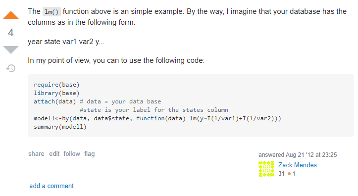

[*Linear Regression and group by in R*](https://stackoverflow.com/a/12064463/3806250)

```r
## https://stackoverflow.com/a/24133767/3806250
```

## 3.5 时间序列模型

上个章节谈及最优三个模型，这儿咱们得先瞧瞧*图表3.1：每日观测值*每日观测值再决定数据多寡。

### 3.5.1 30天数据

```r
##https://stackoverflow.com/questions/24133356/how-to-replicate-a-ddply-behavior-that-uses-a-custom-function-with-dplyr/24133767#24133767
```

### 3.5.2 40天数据

# 4 绘图

## 4.1 投注人数

## 4.2 投注金额

## 4.3 中奖金额

## 4.4 撤单金额

## 4.5 返点金额

## 4.6 盈利

## 4.7 盈率

# 5 结论

## 5.1 总结

${\color{Black} \circledR} {\color{DarkGreen} \gamma} {\color{Red} \sigma} \; {\color{Blue} \xi} {\color{Red} \eta} {\color{Blue} g}$[^9] 🎏[^10]

## 5.2 附录

```r
suppressMessages(require('dplyr', quietly = TRUE))
suppressMessages(require('magrittr', quietly = TRUE))
suppressMessages(require('formattable', quietly = TRUE))
suppressMessages(require('knitr', quietly = TRUE))
suppressMessages(require('kableExtra', quietly = TRUE))

sys1 <- devtools::session_info()$platform %>%
  unlist %>% data.frame(Category = names(.), session_info = .)
rownames(sys1) <- NULL

sys2 <- data.frame(Sys.info()) %>% mutate(Category = rownames(.)) %>% .[2:1]
names(sys2)[2] <- c('Sys.info')
rownames(sys2) <- NULL

if (nrow(sys1) == 9 & nrow(sys2) == 8) {
  sys2 %<>% rbind(., data.frame(
  Category = 'Current time',
  Sys.info = paste(as.character(lubridate::now('Asia/Tokyo')), 'JST🗾')))
} else {
  sys1 %<>% rbind(., data.frame(
  Category = 'Current time',
  session_info = paste(as.character(lubridate::now('Asia/Tokyo')), 'JST🗾')))
}

cbind(sys1, sys2) %>%
  kbl(caption = 'Additional session information:') %>%
  kable_styling(bootstrap_options = c('striped', 'hover', 'condensed', 'responsive')) %>%
  row_spec(9, bold = T, color = 'white', background = '#D7261E')
```

Additional session information:

| Category | session_info | Category | Sys.info |
| --- | --- | --- | --- |
| version | R version 4.0.3 (2020-10-10) | sysname | Linux |
| os | Ubuntu 16.04.7 LTS | release | 5.3.0-1017-aws |
| system | x86_64, linux-gnu | version | #18~18.04.1-Ubuntu SMP Wed Apr 8 15:12:16 UTC 2020 |
| ui | X11 | nodename | application-2789879-deployment-7199315-rzfxp |
| language | (EN) | machine | x86_64 |
| collate | C.UTF-8 | login | unknown |
| ctype | C.UTF-8 | user | rstudio-user |
| tz | Etc/UTC | effective_user | rstudio-user |
| date | 2020-11-02 | Current time | 2020-11-03 05:30:22 JST🗾 |

## 5.3 参考文献

1. [Free themes for Bootstrap](https://bootswatch.com/3/)
2. [R packages for optimal stratified sampling: a review and compared evaluation](https://www.researchgate.net/publication/327791484_R_packages_for_optimal_stratified_sampling_a_review_and_compared_evaluation/comments)
3. [Use of models in SamplingStrata](https://cran.r-project.org/web/packages/SamplingStrata/vignettes/models.html)
4. [Example of Using a Banner Image with RMarkdown](https://rpubs.com/thaufas/555157)
5. [IN R MARKDOWN, How Can I add a background image (HTML output)?](https://stackoverflow.com/questions/60498668/in-r-markdown-how-can-i-add-a-background-image-html-output)
6. [CSS Background Image Size Tutorial – How to Code a Full Page Background Image](https://www.freecodecamp.org/news/css-full-page-background-image-tutorial)

**Powered by - Copyright® Intellectual Property Rights of [Sςιβrοκεrs Trαdιηg®️](http://www.scibrokes.com)経営企業**

[^1]: 基于数据观测值太少[^1]，所以暂时没有预测。
[^2]: [如何 Estimate linear models](https://d.cosx.org/d/419820-estimate-linear-models/7)中的[UNDERSTANDING 3-WAY INTERACTIONS BETWEEN CONTINUOUS VARIABLES](https://tomhouslay.com/2014/03/21/understanding-3-way-interactions-between-continuous-variables/#comment-63365)
[^3]: Section**How to fit a polynomial regression** in [Fitting Polynomial Regression in R](https://www.r-bloggers.com/2015/09/fitting-polynomial-regression-in-r)
[^4]: [Multivariate polynomials in R (`polynom` package)](https://cran.r-project.org/web/packages/multipol/vignettes/multipol.pdf)可供R使用者使用多元非线性模型
[^5]: [binary.com 面试试题 I - GARCH模型中的ARIMA(p,d,q)参数最优化](https://rpubs.com/englianhu/binary-Q1FiGJRGARCH)虽然是单变量模型，不过会自动高效处理并筛选最优`arima(p,d,q)`参数
[^6]: 多相互作用和内嵌线性模型
[^7]: 原稿:[Using R and lme/lmer to fit different two- and three-level longitudinal models](https://rpsychologist.com/r-guide-longitudinal-lme-lmer)多元内嵌线型模型
[^8]: 内嵌多项式线型模型(Polynomial Regression)
[^9]: [Latex Equation](https://www.codecogs.com/latex/eqneditor.php)
[^10]: [Emoji list](https://gist.github.com/rxaviers/7360908)